# Risk Factor Analysis

## Outcome Variable

**Outcome Variable:** ever_wasted

## Predictor Variables

**Intervention Variable:** meducyrs

**Adjustment Set:**

unadjusted

## Stratifying Variables

The analysis was stratified on these variable(s):

- agecat
- studyid
- country

## Data Summary

| agecat | studyid | country | meducyrs | ever_wasted | n_cell | n |
| --- | --- | --- | --- | --- | --- | --- |
| 0-24 months | ki0047075b-MAL-ED | BANGLADESH | Low | 0 | 46 | 213 |
| 0-24 months | ki0047075b-MAL-ED | BANGLADESH | Low | 1 | 24 | 213 |
| 0-24 months | ki0047075b-MAL-ED | BANGLADESH | Medium | 0 | 44 | 213 |
| 0-24 months | ki0047075b-MAL-ED | BANGLADESH | Medium | 1 | 21 | 213 |
| 0-24 months | ki0047075b-MAL-ED | BANGLADESH | High | 0 | 59 | 213 |
| 0-24 months | ki0047075b-MAL-ED | BANGLADESH | High | 1 | 19 | 213 |
| 0-24 months | ki0047075b-MAL-ED | BRAZIL | Low | 0 | 55 | 232 |
| 0-24 months | ki0047075b-MAL-ED | BRAZIL | Low | 1 | 8 | 232 |
| 0-24 months | ki0047075b-MAL-ED | BRAZIL | Medium | 0 | 82 | 232 |
| 0-24 months | ki0047075b-MAL-ED | BRAZIL | Medium | 1 | 8 | 232 |
| 0-24 months | ki0047075b-MAL-ED | BRAZIL | High | 0 | 76 | 232 |
| 0-24 months | ki0047075b-MAL-ED | BRAZIL | High | 1 | 3 | 232 |
| 0-24 months | ki0047075b-MAL-ED | INDIA | Low | 0 | 33 | 220 |
| 0-24 months | ki0047075b-MAL-ED | INDIA | Low | 1 | 43 | 220 |
| 0-24 months | ki0047075b-MAL-ED | INDIA | Medium | 0 | 44 | 220 |
| 0-24 months | ki0047075b-MAL-ED | INDIA | Medium | 1 | 37 | 220 |
| 0-24 months | ki0047075b-MAL-ED | INDIA | High | 0 | 39 | 220 |
| 0-24 months | ki0047075b-MAL-ED | INDIA | High | 1 | 24 | 220 |
| 0-24 months | ki0047075b-MAL-ED | NEPAL | Low | 0 | 69 | 225 |
| 0-24 months | ki0047075b-MAL-ED | NEPAL | Low | 1 | 27 | 225 |
| 0-24 months | ki0047075b-MAL-ED | NEPAL | Medium | 0 | 51 | 225 |
| 0-24 months | ki0047075b-MAL-ED | NEPAL | Medium | 1 | 25 | 225 |
| 0-24 months | ki0047075b-MAL-ED | NEPAL | High | 0 | 40 | 225 |
| 0-24 months | ki0047075b-MAL-ED | NEPAL | High | 1 | 13 | 225 |
| 0-24 months | ki0047075b-MAL-ED | PERU | Low | 0 | 93 | 301 |
| 0-24 months | ki0047075b-MAL-ED | PERU | Low | 1 | 11 | 301 |
| 0-24 months | ki0047075b-MAL-ED | PERU | Medium | 0 | 95 | 301 |
| 0-24 months | ki0047075b-MAL-ED | PERU | Medium | 1 | 12 | 301 |
| 0-24 months | ki0047075b-MAL-ED | PERU | High | 0 | 87 | 301 |
| 0-24 months | ki0047075b-MAL-ED | PERU | High | 1 | 3 | 301 |

[output cut: 438 more lines]

The following strata were considered:

- agecat: 0-24 months, studyid: ki0047075b-MAL-ED, country: BANGLADESH
- agecat: 0-24 months, studyid: ki0047075b-MAL-ED, country: BRAZIL
- agecat: 0-24 months, studyid: ki0047075b-MAL-ED, country: INDIA
- agecat: 0-24 months, studyid: ki0047075b-MAL-ED, country: NEPAL
- agecat: 0-24 months, studyid: ki0047075b-MAL-ED, country: PERU
- agecat: 0-24 months, studyid: ki0047075b-MAL-ED, country: SOUTH AFRICA
- agecat: 0-24 months, studyid: ki0047075b-MAL-ED, country: TANZANIA, UNITED REPUBLIC OF
- agecat: 0-24 months, studyid: ki1000108-CMC-V-BCS-2002, country: INDIA
- agecat: 0-24 months, studyid: ki1000108-IRC, country: INDIA
- agecat: 0-24 months, studyid: ki1000109-EE, country: PAKISTAN
- agecat: 0-24 months, studyid: ki1000304b-SAS-CompFeed, country: INDIA
- agecat: 0-24 months, studyid: ki1000304b-SAS-FoodSuppl, country: INDIA
- agecat: 0-24 months, studyid: ki1017093-NIH-Birth, country: BANGLADESH
- agecat: 0-24 months, studyid: ki1017093b-PROVIDE, country: BANGLADESH
- agecat: 0-24 months, studyid: ki1017093c-NIH-Crypto, country: BANGLADESH
- agecat: 0-24 months, studyid: ki1066203-TanzaniaChild2, country: TANZANIA, UNITED REPUBLIC OF
- agecat: 0-24 months, studyid: ki1112895-Guatemala BSC, country: GUATEMALA
- agecat: 0-24 months, studyid: ki1113344-GMS-Nepal, country: NEPAL
- agecat: 0-24 months, studyid: ki1119695-PROBIT, country: BELARUS
- agecat: 0-24 months, studyid: ki1126311-ZVITAMBO, country: ZIMBABWE
- agecat: 0-24 months, studyid: ki1135781-COHORTS, country: GUATEMALA
- agecat: 0-24 months, studyid: ki1135781-COHORTS, country: INDIA
- agecat: 0-24 months, studyid: ki1135781-COHORTS, country: PHILIPPINES
- agecat: 0-24 months, studyid: ki1148112-LCNI-5, country: MALAWI
- agecat: 0-24 months, studyid: kiGH5241-JiVitA-3, country: BANGLADESH
- agecat: 0-24 months, studyid: kiGH5241-JiVitA-4, country: BANGLADESH
- agecat: 0-6 months, studyid: ki0047075b-MAL-ED, country: BANGLADESH
- agecat: 0-6 months, studyid: ki0047075b-MAL-ED, country: BRAZIL
- agecat: 0-6 months, studyid: ki0047075b-MAL-ED, country: INDIA
- agecat: 0-6 months, studyid: ki0047075b-MAL-ED, country: NEPAL
- agecat: 0-6 months, studyid: ki0047075b-MAL-ED, country: PERU
- agecat: 0-6 months, studyid: ki0047075b-MAL-ED, country: SOUTH AFRICA
- agecat: 0-6 months, studyid: ki0047075b-MAL-ED, country: TANZANIA, UNITED REPUBLIC OF
- agecat: 0-6 months, studyid: ki1000108-CMC-V-BCS-2002, country: INDIA
- agecat: 0-6 months, studyid: ki1000108-IRC, country: INDIA
- agecat: 0-6 months, studyid: ki1000109-EE, country: PAKISTAN
- agecat: 0-6 months, studyid: ki1000304b-SAS-CompFeed, country: INDIA
- agecat: 0-6 months, studyid: ki1000304b-SAS-FoodSuppl, country: INDIA
- agecat: 0-6 months, studyid: ki1017093-NIH-Birth, country: BANGLADESH
- agecat: 0-6 months, studyid: ki1017093b-PROVIDE, country: BANGLADESH
- agecat: 0-6 months, studyid: ki1017093c-NIH-Crypto, country: BANGLADESH
- agecat: 0-6 months, studyid: ki1066203-TanzaniaChild2, country: TANZANIA, UNITED REPUBLIC OF
- agecat: 0-6 months, studyid: ki1112895-Guatemala BSC, country: GUATEMALA
- agecat: 0-6 months, studyid: ki1113344-GMS-Nepal, country: NEPAL
- agecat: 0-6 months, studyid: ki1119695-PROBIT, country: BELARUS
- agecat: 0-6 months, studyid: ki1126311-ZVITAMBO, country: ZIMBABWE
- agecat: 0-6 months, studyid: ki1135781-COHORTS, country: GUATEMALA
- agecat: 0-6 months, studyid: ki1135781-COHORTS, country: INDIA
- agecat: 0-6 months, studyid: ki1135781-COHORTS, country: PHILIPPINES
- agecat: 0-6 months, studyid: ki1148112-LCNI-5, country: MALAWI
- agecat: 0-6 months, studyid: kiGH5241-JiVitA-3, country: BANGLADESH
- agecat: 0-6 months, studyid: kiGH5241-JiVitA-4, country: BANGLADESH
- agecat: 6-24 months, studyid: ki0047075b-MAL-ED, country: BANGLADESH
- agecat: 6-24 months, studyid: ki0047075b-MAL-ED, country: BRAZIL
- agecat: 6-24 months, studyid: ki0047075b-MAL-ED, country: INDIA
- agecat: 6-24 months, studyid: ki0047075b-MAL-ED, country: NEPAL
- agecat: 6-24 months, studyid: ki0047075b-MAL-ED, country: PERU
- agecat: 6-24 months, studyid: ki0047075b-MAL-ED, country: SOUTH AFRICA
- agecat: 6-24 months, studyid: ki0047075b-MAL-ED, country: TANZANIA, UNITED REPUBLIC OF
- agecat: 6-24 months, studyid: ki1000108-CMC-V-BCS-2002, country: INDIA
- agecat: 6-24 months, studyid: ki1000108-IRC, country: INDIA
- agecat: 6-24 months, studyid: ki1000109-EE, country: PAKISTAN
- agecat: 6-24 months, studyid: ki1000304b-SAS-CompFeed, country: INDIA
- agecat: 6-24 months, studyid: ki1000304b-SAS-FoodSuppl, country: INDIA
- agecat: 6-24 months, studyid: ki1017093-NIH-Birth, country: BANGLADESH
- agecat: 6-24 months, studyid: ki1017093b-PROVIDE, country: BANGLADESH
- agecat: 6-24 months, studyid: ki1017093c-NIH-Crypto, country: BANGLADESH
- agecat: 6-24 months, studyid: ki1066203-TanzaniaChild2, country: TANZANIA, UNITED REPUBLIC OF
- agecat: 6-24 months, studyid: ki1112895-Guatemala BSC, country: GUATEMALA
- agecat: 6-24 months, studyid: ki1113344-GMS-Nepal, country: NEPAL
- agecat: 6-24 months, studyid: ki1119695-PROBIT, country: BELARUS
- agecat: 6-24 months, studyid: ki1126311-ZVITAMBO, country: ZIMBABWE
- agecat: 6-24 months, studyid: ki1135781-COHORTS, country: GUATEMALA
- agecat: 6-24 months, studyid: ki1135781-COHORTS, country: INDIA
- agecat: 6-24 months, studyid: ki1135781-COHORTS, country: PHILIPPINES
- agecat: 6-24 months, studyid: ki1148112-LCNI-5, country: MALAWI
- agecat: 6-24 months, studyid: kiGH5241-JiVitA-3, country: BANGLADESH
- agecat: 6-24 months, studyid: kiGH5241-JiVitA-4, country: BANGLADESH

### Dropped Strata

Some strata were dropped due to rare outcomes:

- agecat: 0-24 months, studyid: ki0047075b-MAL-ED, country: BRAZIL
- agecat: 0-24 months, studyid: ki0047075b-MAL-ED, country: PERU
- agecat: 0-24 months, studyid: ki0047075b-MAL-ED, country: TANZANIA, UNITED REPUBLIC OF
- agecat: 0-6 months, studyid: ki0047075b-MAL-ED, country: BRAZIL
- agecat: 0-6 months, studyid: ki0047075b-MAL-ED, country: PERU
- agecat: 0-6 months, studyid: ki0047075b-MAL-ED, country: TANZANIA, UNITED REPUBLIC OF
- agecat: 0-6 months, studyid: ki1000109-EE, country: PAKISTAN
- agecat: 0-6 months, studyid: ki1000304b-SAS-FoodSuppl, country: INDIA
- agecat: 0-6 months, studyid: ki1112895-Guatemala BSC, country: GUATEMALA
- agecat: 0-6 months, studyid: ki1148112-LCNI-5, country: MALAWI
- agecat: 6-24 months, studyid: ki0047075b-MAL-ED, country: BRAZIL
- agecat: 6-24 months, studyid: ki0047075b-MAL-ED, country: PERU
- agecat: 6-24 months, studyid: ki0047075b-MAL-ED, country: TANZANIA, UNITED REPUBLIC OF
- agecat: 6-24 months, studyid: ki1000109-EE, country: PAKISTAN
- agecat: 6-24 months, studyid: ki1112895-Guatemala BSC, country: GUATEMALA

## Methods Detail

We’re interested in the causal parameters $E[Y_a]$ for all values of $a \in \mathcal{A}$. These parameters represent the mean outcome if, possibly contrary to fact, we intervened to set all units to have $A=a$. Under the randomization and positivity assumptions, these are identified by the statistical parameters $\psi_a=E_W[E_{Y|A,W}(Y|A=a,W)]$. In addition, we’re interested in the mean of $Y$, $E[Y]$ under no intervention (the observed mean). We will estimate these parameters by using SuperLearner to fit the relevant likelihood factors – $E_{Y|A,W}(Y|A=a,W)$ and $p(A=a|W)$, and then updating our likelihood fit using a joint TMLE.

For unadjusted analyses ($W=\{\}$), initial likelihoods were estimated using Lrnr_glm to estimate the simple $E(Y|A)$ and Lrnr_mean to estimate $p(A)$. For adjusted analyses, a small library containing Lrnr_glmnet, Lrnr_xgboost, and Lrnr_mean was used.

Having estimated these parameters, we will then use the delta method to estimate relative risks and attributable risks relative to a prespecified baseline level of $A$.

# Results Detail

## Results Plots

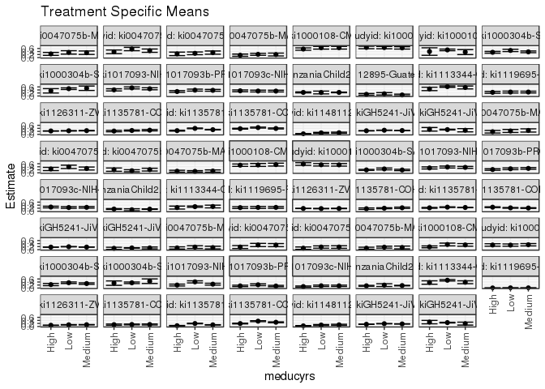

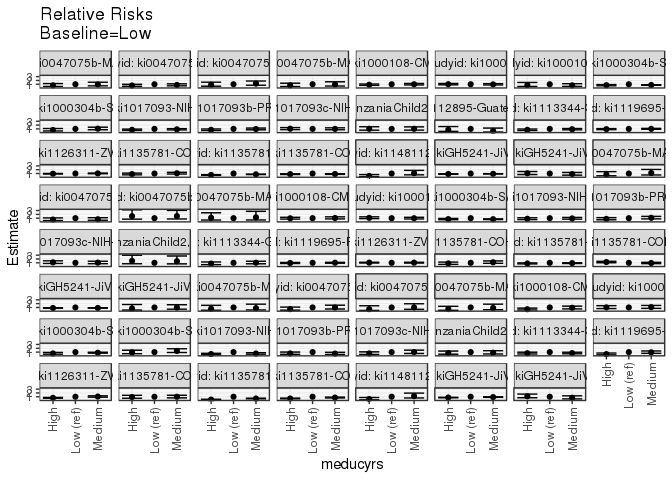

[figure not shown]

[figure not shown]

## Results Table

### Parameter: TSM

| agecat | studyid | country | intervention_level | baseline_level | estimate | ci_lower | ci_upper |
| --- | --- | --- | --- | --- | --- | --- | --- |
| 0-24 months | ki0047075b-MAL-ED | BANGLADESH | Low | NA | 0.3428571 | 0.2314001 | 0.4543142 |
| 0-24 months | ki0047075b-MAL-ED | BANGLADESH | Medium | NA | 0.3230769 | 0.2091213 | 0.4370326 |
| 0-24 months | ki0047075b-MAL-ED | BANGLADESH | High | NA | 0.2435897 | 0.1481057 | 0.3390738 |
| 0-24 months | ki0047075b-MAL-ED | INDIA | Low | NA | 0.5657895 | 0.4541010 | 0.6774779 |
| 0-24 months | ki0047075b-MAL-ED | INDIA | Medium | NA | 0.4567901 | 0.3480632 | 0.5655170 |
| 0-24 months | ki0047075b-MAL-ED | INDIA | High | NA | 0.3809524 | 0.2607634 | 0.5011413 |
| 0-24 months | ki0047075b-MAL-ED | NEPAL | Low | NA | 0.2812500 | 0.1911105 | 0.3713895 |
| 0-24 months | ki0047075b-MAL-ED | NEPAL | Medium | NA | 0.3289474 | 0.2230829 | 0.4348118 |
| 0-24 months | ki0047075b-MAL-ED | NEPAL | High | NA | 0.2452830 | 0.1291908 | 0.3613753 |
| 0-24 months | ki0047075b-MAL-ED | SOUTH AFRICA | Low | NA | 0.2162162 | 0.1497874 | 0.2826450 |
| 0-24 months | ki0047075b-MAL-ED | SOUTH AFRICA | Medium | NA | 0.2028986 | 0.1078563 | 0.2979408 |
| 0-24 months | ki0047075b-MAL-ED | SOUTH AFRICA | High | NA | 0.1578947 | 0.0844517 | 0.2313377 |
| 0-24 months | ki1000108-CMC-V-BCS-2002 | INDIA | Low | NA | 0.6509434 | 0.5600782 | 0.7418086 |
| 0-24 months | ki1000108-CMC-V-BCS-2002 | INDIA | Medium | NA | 0.6513761 | 0.5617959 | 0.7409564 |
| 0-24 months | ki1000108-CMC-V-BCS-2002 | INDIA | High | NA | 0.5632911 | 0.4858512 | 0.6407311 |
| 0-24 months | ki1000108-IRC | INDIA | Low | NA | 0.6598639 | 0.5831855 | 0.7365424 |
| 0-24 months | ki1000108-IRC | INDIA | Medium | NA | 0.6402878 | 0.5604081 | 0.7201674 |
| 0-24 months | ki1000108-IRC | INDIA | High | NA | 0.6693548 | 0.5864506 | 0.7522591 |
| 0-24 months | ki1000109-EE | PAKISTAN | Low | NA | 0.5075988 | 0.4535051 | 0.5616925 |
| 0-24 months | ki1000109-EE | PAKISTAN | Medium | NA | 0.3636364 | 0.1992922 | 0.5279805 |
| 0-24 months | ki1000109-EE | PAKISTAN | High | NA | 0.4000000 | 0.1517525 | 0.6482475 |
| 0-24 months | ki1000304b-SAS-CompFeed | INDIA | Low | NA | 0.4721408 | 0.3963949 | 0.5478866 |
| 0-24 months | ki1000304b-SAS-CompFeed | INDIA | Medium | NA | 0.3791749 | 0.3230808 | 0.4352689 |
| 0-24 months | ki1000304b-SAS-CompFeed | INDIA | High | NA | 0.3509317 | 0.2921897 | 0.4096736 |
| 0-24 months | ki1000304b-SAS-FoodSuppl | INDIA | Low | NA | 0.4819277 | 0.4281149 | 0.5357405 |
| 0-24 months | ki1000304b-SAS-FoodSuppl | INDIA | Medium | NA | 0.5111111 | 0.3648851 | 0.6573371 |
| 0-24 months | ki1000304b-SAS-FoodSuppl | INDIA | High | NA | 0.3414634 | 0.1961391 | 0.4867877 |
| 0-24 months | ki1017093-NIH-Birth | BANGLADESH | Low | NA | 0.5350877 | 0.4702949 | 0.5998805 |
| 0-24 months | ki1017093-NIH-Birth | BANGLADESH | Medium | NA | 0.4770642 | 0.4107081 | 0.5434203 |
| 0-24 months | ki1017093-NIH-Birth | BANGLADESH | High | NA | 0.4044944 | 0.3323362 | 0.4766526 |

[output cut: 159 more lines]

### Parameter: E(Y)

| agecat | studyid | country | intervention_level | baseline_level | estimate | ci_lower | ci_upper |
| --- | --- | --- | --- | --- | --- | --- | --- |
| 0-24 months | ki0047075b-MAL-ED | BANGLADESH | NA | NA | 0.3004695 | 0.2387555 | 0.3621835 |
| 0-24 months | ki0047075b-MAL-ED | INDIA | NA | NA | 0.4727273 | 0.4066048 | 0.5388497 |
| 0-24 months | ki0047075b-MAL-ED | NEPAL | NA | NA | 0.2888889 | 0.2295338 | 0.3482440 |
| 0-24 months | ki0047075b-MAL-ED | SOUTH AFRICA | NA | NA | 0.1955128 | 0.1514355 | 0.2395901 |
| 0-24 months | ki1000108-CMC-V-BCS-2002 | INDIA | NA | NA | 0.6139410 | 0.5644682 | 0.6634139 |
| 0-24 months | ki1000108-IRC | INDIA | NA | NA | 0.6560976 | 0.6100625 | 0.7021326 |
| 0-24 months | ki1000109-EE | PAKISTAN | NA | NA | 0.4907162 | 0.4401862 | 0.5412462 |
| 0-24 months | ki1000304b-SAS-CompFeed | INDIA | NA | NA | 0.4150694 | 0.3581204 | 0.4720184 |
| 0-24 months | ki1000304b-SAS-FoodSuppl | INDIA | NA | NA | 0.4712919 | 0.4233811 | 0.5192026 |
| 0-24 months | ki1017093-NIH-Birth | BANGLADESH | NA | NA | 0.4775641 | 0.4383415 | 0.5167867 |
| 0-24 months | ki1017093b-PROVIDE | BANGLADESH | NA | NA | 0.3514286 | 0.3160364 | 0.3868207 |
| 0-24 months | ki1017093c-NIH-Crypto | BANGLADESH | NA | NA | 0.3311346 | 0.2976093 | 0.3646598 |
| 0-24 months | ki1066203-TanzaniaChild2 | TANZANIA, UNITED REPUBLIC OF | NA | NA | 0.2367980 | 0.2197367 | 0.2538593 |
| 0-24 months | ki1112895-Guatemala BSC | GUATEMALA | NA | NA | 0.1063830 | 0.0703329 | 0.1424331 |
| 0-24 months | ki1113344-GMS-Nepal | NEPAL | NA | NA | 0.5909850 | 0.5515796 | 0.6303903 |
| 0-24 months | ki1119695-PROBIT | BELARUS | NA | NA | 0.2565984 | 0.1993515 | 0.3138454 |
| 0-24 months | ki1126311-ZVITAMBO | ZIMBABWE | NA | NA | 0.2346433 | 0.2276029 | 0.2416837 |
| 0-24 months | ki1135781-COHORTS | GUATEMALA | NA | NA | 0.2564297 | 0.2328823 | 0.2799770 |
| 0-24 months | ki1135781-COHORTS | INDIA | NA | NA | 0.3329911 | 0.3209071 | 0.3450751 |
| 0-24 months | ki1135781-COHORTS | PHILIPPINES | NA | NA | 0.4036125 | 0.3861835 | 0.4210415 |
| 0-24 months | ki1148112-LCNI-5 | MALAWI | NA | NA | 0.0798526 | 0.0612199 | 0.0984853 |
| 0-24 months | kiGH5241-JiVitA-3 | BANGLADESH | NA | NA | 0.2581148 | 0.2516506 | 0.2645791 |
| 0-24 months | kiGH5241-JiVitA-4 | BANGLADESH | NA | NA | 0.3168617 | 0.2936158 | 0.3401077 |
| 0-6 months | ki0047075b-MAL-ED | BANGLADESH | NA | NA | 0.2206573 | 0.1648355 | 0.2764790 |
| 0-6 months | ki0047075b-MAL-ED | INDIA | NA | NA | 0.3136364 | 0.2521871 | 0.3750856 |
| 0-6 months | ki0047075b-MAL-ED | NEPAL | NA | NA | 0.1777778 | 0.1277101 | 0.2278455 |
| 0-6 months | ki0047075b-MAL-ED | SOUTH AFRICA | NA | NA | 0.1025641 | 0.0688457 | 0.1362825 |
| 0-6 months | ki1000108-CMC-V-BCS-2002 | INDIA | NA | NA | 0.5190217 | 0.4679041 | 0.5701394 |
| 0-6 months | ki1000108-IRC | INDIA | NA | NA | 0.5439024 | 0.4956326 | 0.5921723 |
| 0-6 months | ki1000304b-SAS-CompFeed | INDIA | NA | NA | 0.2199336 | 0.1753445 | 0.2645227 |
| 0-6 months | ki1017093-NIH-Birth | BANGLADESH | NA | NA | 0.3569132 | 0.3192325 | 0.3945938 |
| 0-6 months | ki1017093b-PROVIDE | BANGLADESH | NA | NA | 0.2585714 | 0.2261125 | 0.2910304 |
| 0-6 months | ki1017093c-NIH-Crypto | BANGLADESH | NA | NA | 0.2585752 | 0.2273844 | 0.2897660 |
| 0-6 months | ki1066203-TanzaniaChild2 | TANZANIA, UNITED REPUBLIC OF | NA | NA | 0.1395641 | 0.1256566 | 0.1534717 |
| 0-6 months | ki1113344-GMS-Nepal | NEPAL | NA | NA | 0.2954925 | 0.2589234 | 0.3320615 |
| 0-6 months | ki1119695-PROBIT | BELARUS | NA | NA | 0.2497780 | 0.1917926 | 0.3077635 |
| 0-6 months | ki1126311-ZVITAMBO | ZIMBABWE | NA | NA | 0.1809503 | 0.1745333 | 0.1873674 |
| 0-6 months | ki1135781-COHORTS | GUATEMALA | NA | NA | 0.2007612 | 0.1765324 | 0.2249900 |
| 0-6 months | ki1135781-COHORTS | INDIA | NA | NA | 0.2511554 | 0.2398221 | 0.2624886 |
| 0-6 months | ki1135781-COHORTS | PHILIPPINES | NA | NA | 0.2355453 | 0.2204685 | 0.2506222 |
| 0-6 months | kiGH5241-JiVitA-3 | BANGLADESH | NA | NA | 0.1763390 | 0.1707116 | 0.1819665 |
| 0-6 months | kiGH5241-JiVitA-4 | BANGLADESH | NA | NA | 0.1126043 | 0.0962730 | 0.1289355 |
| 6-24 months | ki0047075b-MAL-ED | BANGLADESH | NA | NA | 0.1384615 | 0.0898601 | 0.1870630 |
| 6-24 months | ki0047075b-MAL-ED | INDIA | NA | NA | 0.2657005 | 0.2053824 | 0.3260185 |
| 6-24 months | ki0047075b-MAL-ED | NEPAL | NA | NA | 0.1545455 | 0.1066715 | 0.2024194 |
| 6-24 months | ki0047075b-MAL-ED | SOUTH AFRICA | NA | NA | 0.1389961 | 0.0967835 | 0.1812087 |
| 6-24 months | ki1000108-CMC-V-BCS-2002 | INDIA | NA | NA | 0.2654155 | 0.2205451 | 0.3102860 |
| 6-24 months | ki1000108-IRC | INDIA | NA | NA | 0.3097561 | 0.2649438 | 0.3545684 |
| 6-24 months | ki1000304b-SAS-CompFeed | INDIA | NA | NA | 0.3059755 | 0.2638053 | 0.3481458 |
| 6-24 months | ki1000304b-SAS-FoodSuppl | INDIA | NA | NA | 0.3557214 | 0.3088651 | 0.4025777 |
| 6-24 months | ki1017093-NIH-Birth | BANGLADESH | NA | NA | 0.2939002 | 0.2554778 | 0.3323226 |
| 6-24 months | ki1017093b-PROVIDE | BANGLADESH | NA | NA | 0.1609756 | 0.1319065 | 0.1900447 |
| 6-24 months | ki1017093c-NIH-Crypto | BANGLADESH | NA | NA | 0.1315069 | 0.1069744 | 0.1560393 |
| 6-24 months | ki1066203-TanzaniaChild2 | TANZANIA, UNITED REPUBLIC OF | NA | NA | 0.1606166 | 0.1445647 | 0.1766685 |
| 6-24 months | ki1113344-GMS-Nepal | NEPAL | NA | NA | 0.4735945 | 0.4331684 | 0.5140207 |
| 6-24 months | ki1119695-PROBIT | BELARUS | NA | NA | 0.0100615 | 0.0072668 | 0.0128561 |
| 6-24 months | ki1126311-ZVITAMBO | ZIMBABWE | NA | NA | 0.0940163 | 0.0884807 | 0.0995519 |
| 6-24 months | ki1135781-COHORTS | GUATEMALA | NA | NA | 0.1277129 | 0.1088047 | 0.1466210 |
| 6-24 months | ki1135781-COHORTS | INDIA | NA | NA | 0.1266654 | 0.1178579 | 0.1354730 |
| 6-24 months | ki1135781-COHORTS | PHILIPPINES | NA | NA | 0.2666429 | 0.2502871 | 0.2829988 |
| 6-24 months | ki1148112-LCNI-5 | MALAWI | NA | NA | 0.0772105 | 0.0587369 | 0.0956840 |
| 6-24 months | kiGH5241-JiVitA-3 | BANGLADESH | NA | NA | 0.1638889 | 0.1577625 | 0.1700152 |
| 6-24 months | kiGH5241-JiVitA-4 | BANGLADESH | NA | NA | 0.2529335 | 0.2320005 | 0.2738666 |

### Parameter: RR

| agecat | studyid | country | intervention_level | baseline_level | estimate | ci_lower | ci_upper |
| --- | --- | --- | --- | --- | --- | --- | --- |
| 0-24 months | ki0047075b-MAL-ED | BANGLADESH | Low | Low | 1.0000000 | 1.0000000 | 1.0000000 |
| 0-24 months | ki0047075b-MAL-ED | BANGLADESH | Medium | Low | 0.9423077 | 0.5832726 | 1.5223480 |
| 0-24 months | ki0047075b-MAL-ED | BANGLADESH | High | Low | 0.7104701 | 0.4269554 | 1.1822495 |
| 0-24 months | ki0047075b-MAL-ED | INDIA | Low | Low | 1.0000000 | 1.0000000 | 1.0000000 |
| 0-24 months | ki0047075b-MAL-ED | INDIA | Medium | Low | 0.8073500 | 0.5926045 | 1.0999140 |
| 0-24 months | ki0047075b-MAL-ED | INDIA | High | Low | 0.6733112 | 0.4640741 | 0.9768870 |
| 0-24 months | ki0047075b-MAL-ED | NEPAL | Low | Low | 1.0000000 | 1.0000000 | 1.0000000 |
| 0-24 months | ki0047075b-MAL-ED | NEPAL | Medium | Low | 1.1695906 | 0.7426439 | 1.8419895 |
| 0-24 months | ki0047075b-MAL-ED | NEPAL | High | Low | 0.8721174 | 0.4924147 | 1.5446101 |
| 0-24 months | ki0047075b-MAL-ED | SOUTH AFRICA | Low | Low | 1.0000000 | 1.0000000 | 1.0000000 |
| 0-24 months | ki0047075b-MAL-ED | SOUTH AFRICA | Medium | Low | 0.9384058 | 0.5359244 | 1.6431524 |
| 0-24 months | ki0047075b-MAL-ED | SOUTH AFRICA | High | Low | 0.7302632 | 0.4181994 | 1.2751913 |
| 0-24 months | ki1000108-CMC-V-BCS-2002 | INDIA | Low | Low | 1.0000000 | 1.0000000 | 1.0000000 |
| 0-24 months | ki1000108-CMC-V-BCS-2002 | INDIA | Medium | Low | 1.0006648 | 0.8225957 | 1.2172810 |
| 0-24 months | ki1000108-CMC-V-BCS-2002 | INDIA | High | Low | 0.8653458 | 0.7113802 | 1.0526345 |
| 0-24 months | ki1000108-IRC | INDIA | Low | Low | 1.0000000 | 1.0000000 | 1.0000000 |
| 0-24 months | ki1000108-IRC | INDIA | Medium | Low | 0.9703330 | 0.8182338 | 1.1507055 |
| 0-24 months | ki1000108-IRC | INDIA | High | Low | 1.0143831 | 0.8559409 | 1.2021543 |
| 0-24 months | ki1000109-EE | PAKISTAN | Low | Low | 1.0000000 | 1.0000000 | 1.0000000 |
| 0-24 months | ki1000109-EE | PAKISTAN | Medium | Low | 0.7163854 | 0.4502836 | 1.1397440 |
| 0-24 months | ki1000109-EE | PAKISTAN | High | Low | 0.7880240 | 0.4198203 | 1.4791608 |
| 0-24 months | ki1000304b-SAS-CompFeed | INDIA | Low | Low | 1.0000000 | 1.0000000 | 1.0000000 |
| 0-24 months | ki1000304b-SAS-CompFeed | INDIA | Medium | Low | 0.8030970 | 0.7286090 | 0.8852003 |
| 0-24 months | ki1000304b-SAS-CompFeed | INDIA | High | Low | 0.7432777 | 0.5993648 | 0.9217452 |
| 0-24 months | ki1000304b-SAS-FoodSuppl | INDIA | Low | Low | 1.0000000 | 1.0000000 | 1.0000000 |
| 0-24 months | ki1000304b-SAS-FoodSuppl | INDIA | Medium | Low | 1.0605556 | 0.7801103 | 1.4418193 |
| 0-24 months | ki1000304b-SAS-FoodSuppl | INDIA | High | Low | 0.7085366 | 0.4563247 | 1.1001466 |
| 0-24 months | ki1017093-NIH-Birth | BANGLADESH | Low | Low | 1.0000000 | 1.0000000 | 1.0000000 |
| 0-24 months | ki1017093-NIH-Birth | BANGLADESH | Medium | Low | 0.8915626 | 0.7414147 | 1.0721178 |
| 0-24 months | ki1017093-NIH-Birth | BANGLADESH | High | Low | 0.7559403 | 0.6093281 | 0.9378293 |

[output cut: 159 more lines]

### Parameter: PAR

| agecat | studyid | country | intervention_level | baseline_level | estimate | ci_lower | ci_upper |
| --- | --- | --- | --- | --- | --- | --- | --- |
| 0-24 months | ki0047075b-MAL-ED | BANGLADESH | Low | NA | -0.0423877 | -0.1321994 | 0.0474241 |
| 0-24 months | ki0047075b-MAL-ED | INDIA | Low | NA | -0.0930622 | -0.1837698 | -0.0023546 |
| 0-24 months | ki0047075b-MAL-ED | NEPAL | Low | NA | 0.0076389 | -0.0610249 | 0.0763027 |
| 0-24 months | ki0047075b-MAL-ED | SOUTH AFRICA | Low | NA | -0.0207034 | -0.0672771 | 0.0258703 |
| 0-24 months | ki1000108-CMC-V-BCS-2002 | INDIA | Low | NA | -0.0370024 | -0.1145353 | 0.0405305 |
| 0-24 months | ki1000108-IRC | INDIA | Low | NA | -0.0037664 | -0.0652702 | 0.0577374 |
| 0-24 months | ki1000109-EE | PAKISTAN | Low | NA | -0.0168826 | -0.0361768 | 0.0024116 |
| 0-24 months | ki1000304b-SAS-CompFeed | INDIA | Low | NA | -0.0570714 | -0.0874379 | -0.0267048 |
| 0-24 months | ki1000304b-SAS-FoodSuppl | INDIA | Low | NA | -0.0106358 | -0.0349506 | 0.0136789 |
| 0-24 months | ki1017093-NIH-Birth | BANGLADESH | Low | NA | -0.0575236 | -0.1091828 | -0.0058644 |
| 0-24 months | ki1017093b-PROVIDE | BANGLADESH | Low | NA | -0.0364219 | -0.0903759 | 0.0175321 |
| 0-24 months | ki1017093c-NIH-Crypto | BANGLADESH | Low | NA | 0.0046883 | -0.0441715 | 0.0535481 |
| 0-24 months | ki1066203-TanzaniaChild2 | TANZANIA, UNITED REPUBLIC OF | Low | NA | 0.0050907 | -0.0846912 | 0.0948726 |
| 0-24 months | ki1112895-Guatemala BSC | GUATEMALA | Low | NA | -0.0383539 | -0.1031171 | 0.0264094 |
| 0-24 months | ki1113344-GMS-Nepal | NEPAL | Low | NA | -0.0289675 | -0.0550285 | -0.0029065 |
| 0-24 months | ki1119695-PROBIT | BELARUS | Low | NA | -0.0022540 | -0.0210406 | 0.0165325 |
| 0-24 months | ki1126311-ZVITAMBO | ZIMBABWE | Low | NA | -0.0045912 | -0.0183047 | 0.0091224 |
| 0-24 months | ki1135781-COHORTS | GUATEMALA | Low | NA | -0.0019436 | -0.0267409 | 0.0228538 |
| 0-24 months | ki1135781-COHORTS | INDIA | Low | NA | -0.0647536 | -0.0821544 | -0.0473529 |
| 0-24 months | ki1135781-COHORTS | PHILIPPINES | Low | NA | -0.0458881 | -0.0729912 | -0.0187850 |
| 0-24 months | ki1148112-LCNI-5 | MALAWI | Low | NA | -0.0197643 | -0.0484230 | 0.0088944 |
| 0-24 months | kiGH5241-JiVitA-3 | BANGLADESH | Low | NA | -0.0176658 | -0.0255513 | -0.0097802 |
| 0-24 months | kiGH5241-JiVitA-4 | BANGLADESH | Low | NA | -0.0008127 | -0.0064784 | 0.0048530 |
| 0-6 months | ki0047075b-MAL-ED | BANGLADESH | Low | NA | -0.0079142 | -0.0882139 | 0.0723856 |
| 0-6 months | ki0047075b-MAL-ED | INDIA | Low | NA | -0.0811005 | -0.1678514 | 0.0056505 |
| 0-6 months | ki0047075b-MAL-ED | NEPAL | Low | NA | 0.0423611 | -0.0141806 | 0.0989028 |
| 0-6 months | ki0047075b-MAL-ED | SOUTH AFRICA | Low | NA | 0.0079695 | -0.0274042 | 0.0433432 |
| 0-6 months | ki1000108-CMC-V-BCS-2002 | INDIA | Low | NA | -0.0002090 | -0.0816516 | 0.0812336 |
| 0-6 months | ki1000108-IRC | INDIA | Low | NA | 0.0132902 | -0.0513313 | 0.0779117 |
| 0-6 months | ki1000304b-SAS-CompFeed | INDIA | Low | NA | -0.0363256 | -0.0566777 | -0.0159736 |
| 0-6 months | ki1017093-NIH-Birth | BANGLADESH | Low | NA | -0.0246658 | -0.0744917 | 0.0251601 |
| 0-6 months | ki1017093b-PROVIDE | BANGLADESH | Low | NA | -0.0077837 | -0.0569624 | 0.0413950 |
| 0-6 months | ki1017093c-NIH-Crypto | BANGLADESH | Low | NA | 0.0147735 | -0.0303057 | 0.0598528 |
| 0-6 months | ki1066203-TanzaniaChild2 | TANZANIA, UNITED REPUBLIC OF | Low | NA | 0.0420031 | -0.0215270 | 0.1055333 |
| 0-6 months | ki1113344-GMS-Nepal | NEPAL | Low | NA | -0.0061702 | -0.0297540 | 0.0174136 |
| 0-6 months | ki1119695-PROBIT | BELARUS | Low | NA | -0.0007959 | -0.0199231 | 0.0183312 |
| 0-6 months | ki1126311-ZVITAMBO | ZIMBABWE | Low | NA | 0.0065437 | -0.0057629 | 0.0188504 |
| 0-6 months | ki1135781-COHORTS | GUATEMALA | Low | NA | 0.0027414 | -0.0224420 | 0.0279248 |
| 0-6 months | ki1135781-COHORTS | INDIA | Low | NA | -0.0172018 | -0.0332882 | -0.0011153 |
| 0-6 months | ki1135781-COHORTS | PHILIPPINES | Low | NA | 0.0133231 | -0.0096747 | 0.0363209 |
| 0-6 months | kiGH5241-JiVitA-3 | BANGLADESH | Low | NA | -0.0158894 | -0.0228088 | -0.0089699 |
| 0-6 months | kiGH5241-JiVitA-4 | BANGLADESH | Low | NA | -0.0009870 | -0.0042329 | 0.0022588 |
| 6-24 months | ki0047075b-MAL-ED | BANGLADESH | Low | NA | -0.0307692 | -0.1025049 | 0.0409664 |
| 6-24 months | ki0047075b-MAL-ED | INDIA | Low | NA | -0.0398551 | -0.1241199 | 0.0444098 |
| 6-24 months | ki0047075b-MAL-ED | NEPAL | Low | NA | -0.0174976 | -0.0741137 | 0.0391185 |
| 6-24 months | ki0047075b-MAL-ED | SOUTH AFRICA | Low | NA | -0.0237946 | -0.0661931 | 0.0186040 |
| 6-24 months | ki1000108-CMC-V-BCS-2002 | INDIA | Low | NA | -0.0742071 | -0.1485784 | 0.0001642 |
| 6-24 months | ki1000108-IRC | INDIA | Low | NA | 0.0104364 | -0.0492509 | 0.0701236 |
| 6-24 months | ki1000304b-SAS-CompFeed | INDIA | Low | NA | -0.0458160 | -0.0738002 | -0.0178318 |
| 6-24 months | ki1000304b-SAS-FoodSuppl | INDIA | Low | NA | 0.0088464 | -0.0152647 | 0.0329575 |
| 6-24 months | ki1017093-NIH-Birth | BANGLADESH | Low | NA | -0.1142631 | -0.1670140 | -0.0615122 |
| 6-24 months | ki1017093b-PROVIDE | BANGLADESH | Low | NA | -0.0552406 | -0.1026657 | -0.0078155 |
| 6-24 months | ki1017093c-NIH-Crypto | BANGLADESH | Low | NA | -0.0180658 | -0.0548399 | 0.0187083 |
| 6-24 months | ki1066203-TanzaniaChild2 | TANZANIA, UNITED REPUBLIC OF | Low | NA | -0.0338278 | -0.1233833 | 0.0557277 |
| 6-24 months | ki1113344-GMS-Nepal | NEPAL | Low | NA | -0.0408982 | -0.0669954 | -0.0148010 |
| 6-24 months | ki1119695-PROBIT | BELARUS | Low | NA | -0.0013250 | -0.0033273 | 0.0006773 |
| 6-24 months | ki1126311-ZVITAMBO | ZIMBABWE | Low | NA | -0.0156212 | -0.0268551 | -0.0043873 |
| 6-24 months | ki1135781-COHORTS | GUATEMALA | Low | NA | -0.0023399 | -0.0222347 | 0.0175549 |
| 6-24 months | ki1135781-COHORTS | INDIA | Low | NA | -0.0676553 | -0.0815450 | -0.0537655 |
| 6-24 months | ki1135781-COHORTS | PHILIPPINES | Low | NA | -0.0828258 | -0.1088437 | -0.0568079 |
| 6-24 months | ki1148112-LCNI-5 | MALAWI | Low | NA | -0.0154536 | -0.0434611 | 0.0125538 |
| 6-24 months | kiGH5241-JiVitA-3 | BANGLADESH | Low | NA | -0.0184783 | -0.0264945 | -0.0104621 |
| 6-24 months | kiGH5241-JiVitA-4 | BANGLADESH | Low | NA | -0.0012643 | -0.0066381 | 0.0041096 |

### Parameter: PAF

| agecat | studyid | country | intervention_level | baseline_level | estimate | ci_lower | ci_upper |
| --- | --- | --- | --- | --- | --- | --- | --- |
| 0-24 months | ki0047075b-MAL-ED | BANGLADESH | Low | NA | -0.1410714 | -0.4827438 | 0.1218685 |
| 0-24 months | ki0047075b-MAL-ED | INDIA | Low | NA | -0.1968623 | -0.4076263 | -0.0176561 |
| 0-24 months | ki0047075b-MAL-ED | NEPAL | Low | NA | 0.0264423 | -0.2427496 | 0.2373246 |
| 0-24 months | ki0047075b-MAL-ED | SOUTH AFRICA | Low | NA | -0.1058928 | -0.3710204 | 0.1079645 |
| 0-24 months | ki1000108-CMC-V-BCS-2002 | INDIA | Low | NA | -0.0602702 | -0.1946355 | 0.0589824 |
| 0-24 months | ki1000108-IRC | INDIA | Low | NA | -0.0057406 | -0.1039927 | 0.0837674 |
| 0-24 months | ki1000109-EE | PAKISTAN | Low | NA | -0.0344040 | -0.0746437 | 0.0043289 |
| 0-24 months | ki1000304b-SAS-CompFeed | INDIA | Low | NA | -0.1374984 | -0.2062302 | -0.0726829 |
| 0-24 months | ki1000304b-SAS-FoodSuppl | INDIA | Low | NA | -0.0225674 | -0.0755269 | 0.0277843 |
| 0-24 months | ki1017093-NIH-Birth | BANGLADESH | Low | NA | -0.1204521 | -0.2345396 | -0.0169078 |
| 0-24 months | ki1017093b-PROVIDE | BANGLADESH | Low | NA | -0.1036395 | -0.2684385 | 0.0397483 |
| 0-24 months | ki1017093c-NIH-Crypto | BANGLADESH | Low | NA | 0.0141582 | -0.1450086 | 0.1511994 |
| 0-24 months | ki1066203-TanzaniaChild2 | TANZANIA, UNITED REPUBLIC OF | Low | NA | 0.0214979 | -0.4415893 | 0.3358259 |
| 0-24 months | ki1112895-Guatemala BSC | GUATEMALA | Low | NA | -0.3605263 | -1.1152923 | 0.1249286 |
| 0-24 months | ki1113344-GMS-Nepal | NEPAL | Low | NA | -0.0490157 | -0.0943092 | -0.0055968 |
| 0-24 months | ki1119695-PROBIT | BELARUS | Low | NA | -0.0087843 | -0.0845259 | 0.0616675 |
| 0-24 months | ki1126311-ZVITAMBO | ZIMBABWE | Low | NA | -0.0195665 | -0.0797171 | 0.0372331 |
| 0-24 months | ki1135781-COHORTS | GUATEMALA | Low | NA | -0.0075793 | -0.1090734 | 0.0846269 |
| 0-24 months | ki1135781-COHORTS | INDIA | Low | NA | -0.1944606 | -0.2479721 | -0.1432436 |
| 0-24 months | ki1135781-COHORTS | PHILIPPINES | Low | NA | -0.1136934 | -0.1830072 | -0.0484408 |
| 0-24 months | ki1148112-LCNI-5 | MALAWI | Low | NA | -0.2475096 | -0.6584856 | 0.0616258 |
| 0-24 months | kiGH5241-JiVitA-3 | BANGLADESH | Low | NA | -0.0684415 | -0.0995177 | -0.0382436 |
| 0-24 months | kiGH5241-JiVitA-4 | BANGLADESH | Low | NA | -0.0025648 | -0.0205994 | 0.0151511 |
| 0-6 months | ki0047075b-MAL-ED | BANGLADESH | Low | NA | -0.0358663 | -0.4718268 | 0.2709612 |
| 0-6 months | ki0047075b-MAL-ED | INDIA | Low | NA | -0.2585812 | -0.5687942 | -0.0097097 |
| 0-6 months | ki0047075b-MAL-ED | NEPAL | Low | NA | 0.2382812 | -0.1492168 | 0.4951210 |
| 0-6 months | ki0047075b-MAL-ED | SOUTH AFRICA | Low | NA | 0.0777027 | -0.3394415 | 0.3649351 |
| 0-6 months | ki1000108-CMC-V-BCS-2002 | INDIA | Low | NA | -0.0004027 | -0.1702941 | 0.1448255 |
| 0-6 months | ki1000108-IRC | INDIA | Low | NA | 0.0244349 | -0.1019432 | 0.1363191 |
| 0-6 months | ki1000304b-SAS-CompFeed | INDIA | Low | NA | -0.1651665 | -0.2424621 | -0.0926796 |
| 0-6 months | ki1017093-NIH-Birth | BANGLADESH | Low | NA | -0.0691086 | -0.2182759 | 0.0617945 |
| 0-6 months | ki1017093b-PROVIDE | BANGLADESH | Low | NA | -0.0301028 | -0.2389747 | 0.1435566 |
| 0-6 months | ki1017093c-NIH-Crypto | BANGLADESH | Low | NA | 0.0571344 | -0.1343054 | 0.2162644 |
| 0-6 months | ki1066203-TanzaniaChild2 | TANZANIA, UNITED REPUBLIC OF | Low | NA | 0.3009595 | -0.3391616 | 0.6351018 |
| 0-6 months | ki1113344-GMS-Nepal | NEPAL | Low | NA | -0.0208811 | -0.1038892 | 0.0558851 |
| 0-6 months | ki1119695-PROBIT | BELARUS | Low | NA | -0.0031865 | -0.0826601 | 0.0704533 |
| 0-6 months | ki1126311-ZVITAMBO | ZIMBABWE | Low | NA | 0.0361630 | -0.0342978 | 0.1018237 |
| 0-6 months | ki1135781-COHORTS | GUATEMALA | Low | NA | 0.0136549 | -0.1201042 | 0.1314410 |
| 0-6 months | ki1135781-COHORTS | INDIA | Low | NA | -0.0684905 | -0.1344766 | -0.0063424 |
| 0-6 months | ki1135781-COHORTS | PHILIPPINES | Low | NA | 0.0565628 | -0.0462736 | 0.1492916 |
| 0-6 months | kiGH5241-JiVitA-3 | BANGLADESH | Low | NA | -0.0901069 | -0.1300891 | -0.0515393 |
| 0-6 months | kiGH5241-JiVitA-4 | BANGLADESH | Low | NA | -0.0087653 | -0.0378953 | 0.0195472 |
| 6-24 months | ki0047075b-MAL-ED | BANGLADESH | Low | NA | -0.2222222 | -0.8619721 | 0.1977177 |
| 6-24 months | ki0047075b-MAL-ED | INDIA | Low | NA | -0.1500000 | -0.5147812 | 0.1269366 |
| 6-24 months | ki0047075b-MAL-ED | NEPAL | Low | NA | -0.1132195 | -0.5456457 | 0.1982266 |
| 6-24 months | ki0047075b-MAL-ED | SOUTH AFRICA | Low | NA | -0.1711886 | -0.5160436 | 0.0952221 |
| 6-24 months | ki1000108-CMC-V-BCS-2002 | INDIA | Low | NA | -0.2795883 | -0.5924690 | -0.0281809 |
| 6-24 months | ki1000108-IRC | INDIA | Low | NA | 0.0336922 | -0.1795445 | 0.2083802 |
| 6-24 months | ki1000304b-SAS-CompFeed | INDIA | Low | NA | -0.1497375 | -0.2474580 | -0.0596720 |
| 6-24 months | ki1000304b-SAS-FoodSuppl | INDIA | Low | NA | 0.0248689 | -0.0453297 | 0.0903533 |
| 6-24 months | ki1017093-NIH-Birth | BANGLADESH | Low | NA | -0.3887819 | -0.5816571 | -0.2194269 |
| 6-24 months | ki1017093b-PROVIDE | BANGLADESH | Low | NA | -0.3431613 | -0.6686301 | -0.0811757 |
| 6-24 months | ki1017093c-NIH-Crypto | BANGLADESH | Low | NA | -0.1373753 | -0.4534010 | 0.1099341 |
| 6-24 months | ki1066203-TanzaniaChild2 | TANZANIA, UNITED REPUBLIC OF | Low | NA | -0.2106123 | -0.9184570 | 0.2360620 |
| 6-24 months | ki1113344-GMS-Nepal | NEPAL | Low | NA | -0.0863570 | -0.1433762 | -0.0321813 |
| 6-24 months | ki1119695-PROBIT | BELARUS | Low | NA | -0.1316924 | -0.3462030 | 0.0486371 |
| 6-24 months | ki1126311-ZVITAMBO | ZIMBABWE | Low | NA | -0.1661541 | -0.2916428 | -0.0528572 |
| 6-24 months | ki1135781-COHORTS | GUATEMALA | Low | NA | -0.0183213 | -0.1866263 | 0.1261121 |
| 6-24 months | ki1135781-COHORTS | INDIA | Low | NA | -0.5341256 | -0.6439900 | -0.4316033 |
| 6-24 months | ki1135781-COHORTS | PHILIPPINES | Low | NA | -0.3106243 | -0.4118301 | -0.2166734 |
| 6-24 months | ki1148112-LCNI-5 | MALAWI | Low | NA | -0.2001495 | -0.6202508 | 0.1110273 |
| 6-24 months | kiGH5241-JiVitA-3 | BANGLADESH | Low | NA | -0.1127487 | -0.1627788 | -0.0648712 |
| 6-24 months | kiGH5241-JiVitA-4 | BANGLADESH | Low | NA | -0.0049984 | -0.0264533 | 0.0160081 |